# 제 15강: 혼합모형

데이터과학 입문

Author

Affiliation

원중호

서울대학교 통계학과

Published

May 2026

## 시작하기 전에

다음의 패키지가 설치되어 있지 않으면 설치한다.

```r
# install.packages("MASS")
library(MASS)
# install.packages("nlme")
library(nlme)
# install.packages("lme4")
library(lme4)
# install.packages("gee")
library(gee)
```

## 랜덤 효과와 혼합 효과

### 고정 효과 (fixed effects)

- 지금까지 우리가 고려한 모형
- 무작위성의 유일한 원천: 사례를 독립적인 랜덤 표본으로 간주
- 일반화선형모형: 평균이 설명변수의 결정론적 함수인 랜덤 반응변수를 독립적으로 관측

### 랜덤 효과 (random effects)

- 하나의 실험 단위(또는 유사한 실험 단위의 군집)에 대해 둘 이상의 관측값이 있을 때 발생
- 실험 단위는 독립 — 단위/군집 내에서 상관된 (correlated) 관측치
- 랜덤 효과: 실험 단위와 함께 변하는 변량
  - 상관관계를 직접 모형화하지 않음

### 랜덤 효과의 예

- 반복측정 자료(repeated measures): 하나의 피험체에 대해 여러 번의 측정
  - 종단(longitudinal), 패널(panal) 연구, 다수준(multilevel) 분석
- 지분(nested) 설계: 분할구 배치법(split-plot design)

### 혼합 모형의 접근법

- 랜덤 효과의 크기는 분산으로 측정 — 분산성분 모형(variance component models)
- 조건부(conditional)/피험체별(subject-specific) 모형화
  - 회귀 계수는 각 개인에게 적용되지만 반드시 모집단에 적용되는 것은 아님.

## 선형 모형

- 2단계 표본 추출
  - 1단계: 모집단에서 실험단위가 무작위 추출
  - 2단계: 1단계에서 추출된 단위에 대해 복수 번의 측정
- 예) 1997년과 1999년에 측정된 141명의 환자에 대한 자료
  - 단순 회귀 분석은 모든 환자를 독립으로 가정 — 282개 관측값
  - 회귀계수 점추정치은 관찮으나 유의성을 과장할 가능성이 높음
  - 대안: 두 해의 측정값을 평균, 또는 2단계 접근 방식

### `MASS::petrol` 자료

- 정유 공정의 수율(`Y`) 추정
- 예측 변수: 중력(`SG`), 증기압(`VP`), ASTM 10% 지점(`V10`), ASTM endpoint 휘발성 (`EP`)
- 10개 원유 표본(`NO`)에 대한 반복측정 자료로 추정됨

```r
library(lattice)
xyplot(Y ~ EP | No, data = petrol,
       xlab = "ASTM end point (deg. F)",
       ylab = "Yield as percent of crude",
       panel = function(x, y){
           panel.grid()
           m <-  sort.list(x)
           panel.xyplot(x[m], y[m], type = "b", cex = 0.5)
})
```

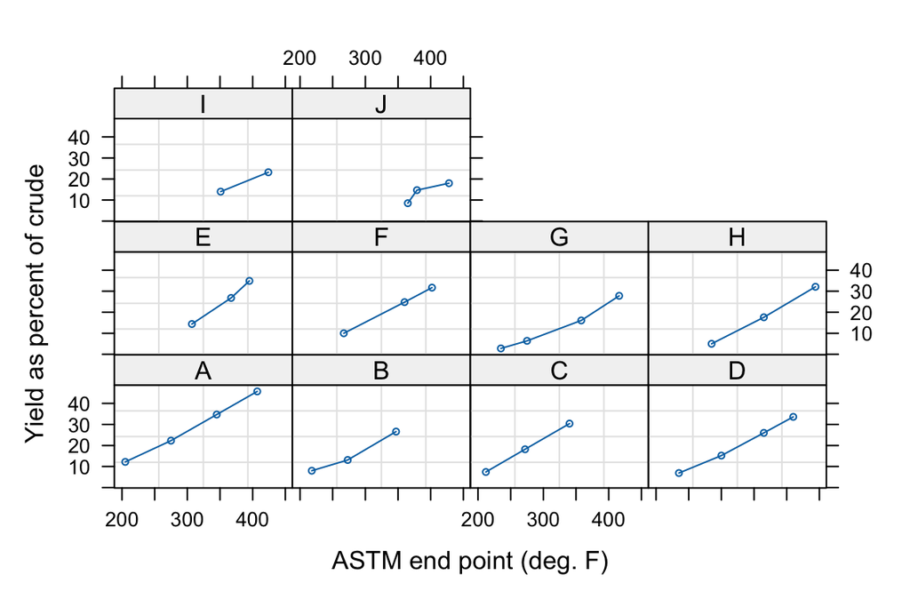

- 수율은 일관되게 선형적으로 증가
- 표본효과에 따른 절편의 변화
  - `V10` 값이 증가하도록 표본이 배열 — `V10`에 대한 유의한 음의 계수 시사
- 10개의 원유 표본을 *고정된 것으로 간주*하면 가장 일반적인 모형은 각 원유 표본에 대해 `Y ~ EP`인 단순 선형 회귀

```r
Petrol <- petrol
names(Petrol)
```

```
[1] "No"  "SG"  "VP"  "V10" "EP"  "Y"
```

```r
Petrol[, 2:5] <- scale(Petrol[, 2:5], scale = F)
pet1.lm <- lm(Y ~ No/EP - 1, Petrol) # Y ~ No + No:EP - 1
matrix(round(coef(pet1.lm), 2),2, 10, byrow  = T,
       dimnames  = list(c ("b0", "b1"), levels(Petrol$No)))
```

```
       A     B     C     D     E     F     G     H     I    J
b0 32.75 23.62 28.99 21.13 19.82 20.42 14.78 12.68 11.62 6.18
b1  0.17  0.15  0.18  0.15  0.23  0.16  0.14  0.17  0.13 0.13
```

- 절편에는 큰 변화가 있고 기울기에는 약간의 변화가 있다.
- 기울기가 일정하다고 할 수 있는지 검정

```r
pet2.lm <- lm(Y ~ No - 1 + EP, Petrol)
anova(pet2.lm, pet1.lm)
```

```
Analysis of Variance Table

Model 1: Y ~ No - 1 + EP
Model 2: Y ~ No/EP - 1
  Res.Df    RSS Df Sum of Sq      F Pr(>F)
1     21 74.132
2     12 30.329  9    43.803 1.9257 0.1439
```

- 절편의 변화 설명

```r
pet3.lm <- lm(Y ~ SG + VP + V10 + EP, Petrol)
anova(pet3.lm, pet2.lm)
```

```
Analysis of Variance Table

Model 1: Y ~ SG + VP + V10 + EP
Model 2: Y ~ No - 1 + EP
  Res.Df     RSS Df Sum of Sq      F  Pr(>F)
1     27 134.804
2     21  74.132  6    60.672 2.8645 0.03368 *
---
Signif. codes:  0 '***' 0.001 '**' 0.01 '*' 0.05 '.' 0.1 ' ' 1
```

- `SG`, `VP`, `V10`은 `No` 수준 내에서 일정하므로 이 두 모형은 중첩(nested)
- 절편 간의 차이가 `SG + VP + V10` 회귀에 의해 적절하게 설명되지 **않음**

### 선형 혼합효과 모형

```r
library(nlme)
pet3.lme <- nlme::lme(Y ~ SG + VP + V10 + EP, random = ~ 1 | No, data = Petrol)
summary(pet3.lme)
```

```
Linear mixed-effects model fit by REML
  Data: Petrol
      AIC      BIC    logLik
  166.382 175.4528 -76.19098

Random effects:
 Formula: ~1 | No
        (Intercept) Residual
StdDev:    1.444741 1.872208

Fixed effects:  Y ~ SG + VP + V10 + EP
                Value Std.Error DF  t-value p-value
(Intercept) 19.706789 0.5682733 21 34.67836  0.0000
SG           0.219398 0.1469378  6  1.49314  0.1860
VP           0.545863 0.5205275  6  1.04867  0.3347
V10         -0.154243 0.0399624  6 -3.85970  0.0084
EP           0.157177 0.0055880 21 28.12756  0.0000
 Correlation:
    (Intr) SG     VP     V10
SG   0.059
VP   0.013  0.067
V10  0.015  0.433  0.836
EP  -0.004  0.023 -0.116 -0.197

Standardized Within-Group Residuals:
       Min         Q1        Med         Q3        Max
-1.7806793 -0.6064447 -0.1068210  0.4571693  1.7811272

Number of Observations: 32
Number of Groups: 10
```

- 그룹 내 잔차 분산: $\widehat{\sigma}^2= 1.8722^2 = 3.51$
- 그룹 간 랜덤 효과의 분산: $\widehat{\sigma}_1^2= 1.444^2 = 2.09$
- 기본 추정 방법: REsidual (or REduced or REstricted) Maximum Likelihood (REML)
  - 선형 모형의 최소 제곱 적합에서 잔차의 주변 가능도를 최대화하여 분산 구조의 매개변수(예: 분산성분)를 추정
  - 고정 효과는 분산 구조가 알려져 있다는 가정 하에 최대 가능도에 의해 추정 — 일반화 최소 제곱법
- 최대 가능도 추정

```r
pet3.lme <- update(pet3.lme, method =  "ML")
summary(pet3.lme)
```

```
Linear mixed-effects model fit by maximum likelihood
  Data: Petrol
       AIC      BIC    logLik
  149.3833 159.6435 -67.69166

Random effects:
 Formula: ~1 | No
        (Intercept) Residual
StdDev:   0.9288872 1.827296

Fixed effects:  Y ~ SG + VP + V10 + EP
                Value Std.Error DF  t-value p-value
(Intercept) 19.694298 0.4781506 21 41.18848  0.0000
SG           0.221329 0.1228151  6  1.80213  0.1216
VP           0.549397 0.4407585  6  1.24648  0.2590
V10         -0.152691 0.0341690  6 -4.46869  0.0042
EP           0.156339 0.0058729 21 26.62036  0.0000
 Correlation:
    (Intr) SG     VP     V10
SG   0.041
VP   0.010  0.057
V10  0.011  0.416  0.839
EP  -0.003  0.030 -0.145 -0.241

Standardized Within-Group Residuals:
       Min         Q1        Med         Q3        Max
-1.8709986 -0.6559407 -0.0979068  0.5430439  1.8186748

Number of Observations: 32
Number of Groups: 10
```

- 랜덤 효과 검정

```r
anova(pet3.lme, pet3.lm)
```

```
         Model df      AIC      BIC    logLik   Test  L.Ratio p-value
pet3.lme     1  7 149.3833 159.6435 -67.69166
pet3.lm      2  6 148.8308 157.6252 -68.41540 1 vs 2 1.447482  0.2289
```

- 랜덤 효과가 무시할 정도로 작지만 계속 사용
- REML과 ML 공히 고정 효과 중 `V10`과 `EP`만이 유용한 예측 변수일 수 있음을 시사
  - 하위 모형 적합 후 가능도비 검정
- 고정 효과에 대한 가설을 검정하려면 검정이 동일한 지료를 기반으로 가능도를 비교할 수 있도록 추정 방법을 *`ML`로 설정*

```r
pet4.lme <- update(pet3.lme, fixed = Y ~ V10 + EP)
anova(pet4.lme, pet3.lme)
```

```
         Model df      AIC      BIC    logLik   Test L.Ratio p-value
pet4.lme     1  5 149.6119 156.9406 -69.80594
pet3.lme     2  7 149.3833 159.6435 -67.69166 1 vs 2 4.22855  0.1207
```

```r
fixed.effects(pet4.lme)
```

```
(Intercept)         V10          EP
 19.6515890  -0.2108053   0.1575859
```

```r
coef(pet4.lme)
```

```
  (Intercept)        V10        EP
A    21.05405 -0.2108053 0.1575859
B    18.33759 -0.2108053 0.1575859
C    21.48569 -0.2108053 0.1575859
D    17.53791 -0.2108053 0.1575859
E    19.45035 -0.2108053 0.1575859
F    19.42200 -0.2108053 0.1575859
G    20.17194 -0.2108053 0.1575859
H    19.84125 -0.2108053 0.1575859
I    19.21157 -0.2108053 0.1575859
J    20.00353 -0.2108053 0.1575859
```

- 랜덤 효과의 ’추정치’는 실제로는 BLUP (best linear unbiased predictors)
- AIC 계산은 6.8절과 같음
- 랜덤 기울기 모형
  $$y_{i j}=\mu+\zeta_i+\beta_3 \mathrm{~V} 10_i+\left(\beta_4+\eta_i\right) \mathrm{EP}_{i j}+\epsilon_{i j}$$
  - $(\zeta_i, \eta_i)$와 $\epsilon_{i j}$는 서로 독립이지만 $\zeta_i$와 $\eta_i$는 상관관계가 있을 수 있음
- 추가 모수: 랜덤 기울기의 분산, 랜덤 기울기와 절편 간의 공분산

```r
pet5.lme <- update(pet4.lme, random = ~ 1 + EP | No)
anova(pet4.lme, pet5.lme)
```

```
         Model df      AIC      BIC    logLik   Test      L.Ratio p-value
pet4.lme     1  5 149.6119 156.9406 -69.80594
pet5.lme     2  7 153.6119 163.8720 -69.80594 1 vs 2 1.476093e-08       1
```

- 검정은 유의하지 않음

### 예측과 적합치

혼합 효과 모형의 적합값과 예측값에 대해 반드시 고려해야 할 것이 있다.

- 기존그룹의 새 데이터 포인트에 대한 예측을 원할 때
  $$\widehat{\mu}+\widehat{\zeta}_i+\widehat{\beta}_3 \mathrm{~V} 10_i+\widehat{\beta}_4 \mathrm{EP}_{i j}$$
  (BLUP)

```r
predict(pet4.lme, Petrol, level=1)
```

```
         A          A          A          A          B          B          B
11.8823441 22.9133558 33.9443675 43.7146922  6.9983979 15.6656214 27.3269766
         C          C          C          D          D          D          D
 7.7253436 17.1804965 27.8963364  6.7696231 17.0127054 27.2557877 34.3471523
         E          E          E          F          F          F          G
17.7093855 27.1645383 31.5769430 10.3235724 24.9790594 31.5976664 -0.5041989
         G          G          G          H          H          H          I
 5.7992364 18.8788646 28.0188457  5.5687654 18.1756359 30.6249205 13.2317059
         I          J          J          J
24.7354752  9.4840904 11.6902927 19.4120009
attr(,"label")
[1] "Predicted values"
```

- 새 그룹의 예측을 원할 때
  $$\widehat{\mu}+\widehat{\beta}_3 \mathrm{~V} 10_i+\widehat{\beta}_4 \mathrm{EP}_{i j}$$

```r
predict(pet4.lme, Petrol, level=0)
```

```
 [1] 10.479883 21.510894 32.541906 42.312231  8.312393 16.979616 28.640971
 [8]  5.891240 15.346393 26.062233  8.883299 19.126382 29.369464 36.460829
[15] 17.910624 27.365777 31.778182 10.553162 25.208649 31.827256 -1.024551
[22]  5.278884 18.358512 27.498494  5.379106 17.985976 30.435261 13.671721
[29] 25.175490  9.132152 11.338355 19.060063
attr(,"label")
[1] "Predicted values"
```

### 다수준 연구

#### `MASS::nlschools` 자료

- 네덜란드의 131개 학교, 133개 학급의 8학년 학생(약 11세) 2,287명을 대상으로 한 연구 (Snijders and Bosker, 1999)
- 반응변수: 언어 시험 점수

```r
# (학급 내) IQ 평균 제거
nl1 <-  nlschools; attach(nl1)
classMeans <- tapply(IQ, class, mean)
nl1$IQave <- classMeans[as.character(class)]
detach(nl1)
cen <- c("IQ",  "IQave",  "SES")
nl1[cen] <- scale(nl1[cen], center = T,  scale = F)
```

- 사회경제적 지위(`SES`), 학급 평균 IQ, 학생 IQ 간의 교호작용 및 다학년 학급에서 교육을 받는지 여부(`COMB`)에 대한 혼합 모형
  - 랜덤 절편 및 IQ의 학급별 랜덤 기울기

```r
options(contrasts =  c("contr.treatment", "contr.poly"))
nl.lme <- nlme::lme(lang ~ IQ*COMB + IQave + SES,
              random = ~ IQ | class, data = nl1)
summary(nl.lme)
```

```
Linear mixed-effects model fit by REML
  Data: nl1
       AIC      BIC    logLik
  15121.25 15178.57 -7550.625

Random effects:
 Formula: ~IQ | class
 Structure: General positive-definite, Log-Cholesky parametrization
            StdDev    Corr
(Intercept) 2.7962960 (Intr)
IQ          0.4227375 -0.576
Residual    6.2576419

Fixed effects:  lang ~ IQ * COMB + IQave + SES
               Value Std.Error   DF   t-value p-value
(Intercept) 41.41524 0.3561987 2151 116.27006  0.0000
IQ           2.11066 0.0962655 2151  21.92539  0.0000
COMB1       -1.66731 0.5890330  130  -2.83059  0.0054
IQave        0.85431 0.3239644  130   2.63705  0.0094
SES          0.15684 0.0146505 2151  10.70517  0.0000
IQ:COMB1     0.46672 0.1754104 2151   2.66075  0.0079
 Correlation:
         (Intr) IQ     COMB1  IQave  SES
IQ       -0.272
COMB1    -0.612  0.155
IQave    -0.074 -0.062  0.149
SES       0.009 -0.200  0.000 -0.100
IQ:COMB1  0.164 -0.509 -0.200 -0.166  0.001

Standardized Within-Group Residuals:
        Min          Q1         Med          Q3         Max
-4.06047300 -0.63967526  0.06435779  0.71639246  2.78778836

Number of Observations: 2287
Number of Groups: 133
```

- 유사한 고정효과 모형

```r
summary(lm(lang ~ IQ*COMB + SES + class, data = nl1, singular.ok = T), cor = F)
```

```
Call:
lm(formula = lang ~ IQ * COMB + SES + class, data = nl1, singular.ok = T)

Residuals:
     Min       1Q   Median       3Q      Max
-24.4959  -3.9732   0.3439   4.4068  18.1766

Coefficients: (1 not defined because of singularities)
            Estimate Std. Error t value Pr(>|t|)
(Intercept) 41.91820    1.28221  32.692  < 2e-16 ***
IQ           2.09357    0.08280  25.284  < 2e-16 ***
COMB1       -9.03614    2.70919  -3.335 0.000866 ***
SES          0.16808    0.01543  10.891  < 2e-16 ***
class280    -0.01463    3.38330  -0.004 0.996551
class1082    2.22705    3.69754   0.602 0.547035
class1280    3.69695    2.90146   1.274 0.202741
class1580   -1.22610    3.27268  -0.375 0.707959
class1680    8.72093    3.27437   2.663 0.007793 **
class1880   -9.51511    1.82491  -5.214 2.02e-07 ***
class2180   -1.90289    1.99029  -0.956 0.339136
class2480    3.58175    1.81263   1.976 0.048283 *
class2680   -3.08949    1.97384  -1.565 0.117678
class2780    1.36623    2.76179   0.495 0.620870
class2980    7.20812    3.15119   2.287 0.022267 *
class3380    6.75740    3.51519   1.922 0.054695 .
class3580    9.21580    2.92360   3.152 0.001643 **
class3680   -6.52635    1.84278  -3.542 0.000406 ***
class3880    0.47093    1.75165   0.269 0.788071
class4081   -3.28007    1.81103  -1.811 0.070255 .
class4082    9.07705    3.13244   2.898 0.003796 **
class4180   -3.33096    2.16492  -1.539 0.124047
class4280    1.76727    2.93292   0.603 0.546864
class4480    6.53638    2.89152   2.261 0.023887 *
class4780    1.03337    3.28475   0.315 0.753098
class4880   -2.74971    2.28658  -1.203 0.229285
class4980    3.46954    3.18702   1.089 0.276433
class5280   -5.27695    1.87961  -2.807 0.005038 **
class5480   -0.68042    1.74959  -0.389 0.697388
class5580   -2.43164    1.74158  -1.396 0.162790
class5780   -2.67800    1.84457  -1.452 0.146695
```

[output cut: 97 more lines]

```
class24380  13.29754    3.26886   4.068 4.91e-05 ***
class24480  -1.18911    2.16118  -0.550 0.582229
class24680   8.21383    3.03145   2.710 0.006791 **
class24980  -1.63956    1.82397  -0.899 0.368808
class25080   6.75619    2.90005   2.330 0.019915 *
class25280  -2.16418    2.29102  -0.945 0.344951
class25680   1.30483    3.11196   0.419 0.675042
class25880        NA         NA      NA       NA
IQ:COMB1     0.40170    0.16213   2.478 0.013299 *
---
Signif. codes:  0 '***' 0.001 '**' 0.01 '*' 0.05 '.' 0.1 ' ' 1

Residual standard error: 6.315 on 2151 degrees of freedom
Multiple R-squared:  0.5372,    Adjusted R-squared:  0.5081
F-statistic: 18.49 on 135 and 2151 DF,  p-value: < 2.2e-16
```

```r
# 학급 규모(`GS`)에 따른 가중치
nl2 <- cbind(aggregate(nl1[c(1,7)], list(class = nl1$class), mean),
unique(nl1[c("class", "COMB", "GS")]))
summary(lm(lang ~ IQave + COMB, data = nl2, weights = GS))
```

```
Call:
lm(formula = lang ~ IQave + COMB, data = nl2, weights = GS)

Weighted Residuals:
    Min      1Q  Median      3Q     Max
-44.217  -8.478   0.825  11.127  45.068

Coefficients:
            Estimate Std. Error t value Pr(>|t|)
(Intercept)  41.2776     0.3702  111.51  < 2e-16 ***
IQave         3.9057     0.2944   13.27  < 2e-16 ***
COMB1        -1.6238     0.5862   -2.77  0.00643 **
---
Signif. codes:  0 '***' 0.001 '**' 0.01 '*' 0.05 '.' 0.1 ' ' 1

Residual standard error: 16.44 on 130 degrees of freedom
Multiple R-squared:  0.6126,    Adjusted R-squared:  0.6066
F-statistic: 102.8 on 2 and 130 DF,  p-value: < 2.2e-16
```

### 종단 연구

#### `MASS::Sitka` 자료

- 79 그루의 Sitka 가문비나무 나무의 원목 크기(원목 높이 + 원목 지름)에 대한 반복 측정 자료
- 54 그루는 오존 농축 챔버에서 재배, 그 중 25 그루는 대조군
- 원목 크기는 1988년에 대략 한달 간격으로 5번 측정

```r
sitka.lme <- nlme::lme(size ~ treat*ordered(Time), random = ~1 | tree, data = Sitka, method = "ML")
attach(Sitka)
Sitka$treatslope <- Time * (treat ==  "ozone")
detach(Sitka)
sitka.lme2 <- update(sitka.lme, fixed = size ~ ordered(Time) + treat + treatslope)
anova(sitka.lme, sitka.lme2)
```

```
           Model df      AIC      BIC    logLik   Test   L.Ratio p-value
sitka.lme      1 12 30.94633 78.69296 -3.473163
sitka.lme2     2  9 25.43446 61.24443 -3.717228 1 vs 2 0.4881304  0.9215
```

```r
# fitted curves
matrix(fitted(sitka.lme2, level = 0) [c(301:305,  1:5)], 2, 5, byrow = T, dimnames  = list(c("control", "ozone"), unique(Sitka$Time)))
```

```
             152      174      201      227      258
control 4.163953 4.621302 5.050896 5.442700 5.646749
ozone   4.060577 4.470879 4.842733 5.178935 5.316690
```

### 랜덤 효과의 공분산 구조 및 잔차

- `lme`의 선형 혼합모형
  $$y_{i j}=\mu_{i j}+\boldsymbol{z}_{i j} \boldsymbol{\zeta}_i+\epsilon_{i j}, \quad \mu_{i j}=\boldsymbol{x}_{i j} \boldsymbol{\beta}$$
  - $i$: 그룹 번호, $j$: 각 그룹의 측정값 번호
  - $\boldsymbol{x}$, $\boldsymbol{z}$: 각 측정값과 연관된 설명 변수의 행 벡터
- 오차항 $\epsilon_{i j}$은 각 그룹에 대해 독립이지만 그룹 내에서는 상관관계가 있을 수 있음
  $$\operatorname{var}\left(\epsilon_{i j}\right)=\sigma^2 g\left(\mu_{i j}, \boldsymbol{z}_{i j}, \theta\right), \quad \operatorname{corr}\left(\epsilon_{i j}\right)=\Gamma(\alpha)$$
  - 오차분산은 평균 및 다른 공변량에 따라 달라질 수 있음.
- 랜덤 효과 $\boldsymbol{\zeta}_{i}$는 $\epsilon_{i j}$와 독립. 분산-공분산 행렬:
  $$\operatorname{var}\left(\boldsymbol{\zeta}_i\right)=D\left(\alpha_\zeta\right)$$
- 기본값: $g \equiv 1$, $\Gamma \equiv I$, $D$는 제약 없음
  - 사용자 정의 함수 사용 가능
- 자유 모수 $(\sigma^2, \theta, \alpha, \alpha_{\zeta})$: 기본적으로 `REML`로 추정

## 다층 모형 (multistratum models)

- 랜덤 변동의 원인이 두 개 이상인 경우 발생
- 표본 정보와 관측값 평균들에 대한 모형을 층(strata)으로 분할

### 분할구 설계

#### `MASS::oats` 자료

|  |  | $N_1$ | $N_2$ | $N_3$ | $N_4$ |  |  | $N_1$ | $N_2$ | $N_3$ | $N_4$ |
| --- | --- | --- | --- | --- | --- | --- | --- | --- | --- | --- | --- |
| $\mathrm{I}$ | $V_1$ | 111 | 130 | 157 | 174 | $\mathrm{IV}$ | $V_1$ | 74 | 89 | 81 | 122 |
|  | $V_2$ | 117 | 114 | 161 | 141 |  | $V_2$ | 64 | 103 | 132 | 133 |
|  | $V_3$ | 105 | 140 | 118 | 156 |  | $V_3$ | 70 | 89 | 104 | 117 |
| $\mathrm{II}$ | $V_1$ | 61 | 91 | 97 | 100 | $\mathrm{~V}$ | $V_1$ | 62 | 90 | 100 | 116 |
|  | $V_2$ | 70 | 108 | 126 | 149 |  | $V_2$ | 80 | 82 | 94 | 126 |
|  | $V_3$ | 96 | 124 | 121 | 144 |  | $V_3$ | 63 | 70 | 109 | 99 |
| $\mathrm{III}$ | $V_1$ | 68 | 64 | 112 | 86 | $\mathrm{VI}$ | $V_1$ | 53 | 74 | 118 | 113 |
|  | $V_2$ | 60 | 102 | 89 | 96 |  | $V_2$ | 89 | 82 | 86 | 104 |
|  | $V_3$ | 89 | 129 | 132 | 124 |  | $V_3$ | 97 | 99 | 119 | 121 |

- Yates (1935, 1937)
- 3개 실험구, 6개 블록(`B`)
  - 각 실험구는 4개의 하위 실험구로 분할
- 총 3개 품종의 귀리(`V`) — 각 실험구에 1개 품종을 파종
- 질소 비료 수준(`N`): 0, 0.2, 0.4, 0.6 cwt per acre
  - 각 실험구의 4개 하위 실험구 각각에 한 수준씩 사용

#### 층화

1. 모든 관측값의 총계(1차원)
2. 블록 총합 간의 대조( 6 -1 = 5차원)
3. 동일 블록 내 품종(실험구) 합계 간의 대조( 6 * (3-1) = 12차원)
4. 실험구 내 대조(3 * 6 * (4-1) = 54차원)
- 층 1: 총평균만 추정 가능
- 층 2: 처리 효과 정보가 없음
- 층 3: `V` 주효과 추정
- 층 4: `N` 주효과와 `N × V` 교호작용 추정

#### `aov` 모형 공식

`response ~ mean.formula + Error (strata.formula)`

- `B/V`로 층 2와 3 지정
- 네 번째 층은 “within” 층으로 자동 포함

```r
oats$Nf <- ordered(oats$N, levels = sort(levels(oats$N)))
oats.aov <- aov(Y ~ Nf*V + Error(B/V), data = oats, qr = T)
summary(oats.aov)
```

```
Error: B
          Df Sum Sq Mean Sq F value Pr(>F)
Residuals  5  15875    3175

Error: B:V
          Df Sum Sq Mean Sq F value Pr(>F)
V          2   1786   893.2   1.485  0.272
Residuals 10   6013   601.3

Error: Within
          Df Sum Sq Mean Sq F value   Pr(>F)
Nf         3  20020    6673  37.686 2.46e-12 ***
Nf:V       6    322      54   0.303    0.932
Residuals 45   7969     177
---
Signif. codes:  0 '***' 0.001 '**' 0.01 '*' 0.05 '.' 0.1 ' ' 1
```

- 분명한 질소 효과가 있으나 품종간 차이나 교호작용의 증거는 없음

#### 분산분석

- 수확량이 질소비료량에 대해 선형적으로 증가하는가?

```r
# `L = 1`: 선형 성분
# `Dev = 2:3`: 2차, 3차항 성분
summary(oats.aov, split = list(Nf = list(L = 1, Dev  = 2:3)))
```

```
Error: B
          Df Sum Sq Mean Sq F value Pr(>F)
Residuals  5  15875    3175

Error: B:V
          Df Sum Sq Mean Sq F value Pr(>F)
V          2   1786   893.2   1.485  0.272
Residuals 10   6013   601.3

Error: Within
            Df Sum Sq Mean Sq F value   Pr(>F)
Nf           3  20020    6673  37.686 2.46e-12 ***
  Nf: L      1  19536   19536 110.323 1.09e-13 ***
  Nf: Dev    2    484     242   1.367    0.265
Nf:V         6    322      54   0.303    0.932
  Nf:V: L    2    168      84   0.475    0.625
  Nf:V: Dev  4    153      38   0.217    0.928
Residuals   45   7969     177
---
Signif. codes:  0 '***' 0.001 '**' 0.01 '*' 0.05 '.' 0.1 ' ' 1
```

#### 잔차 분석

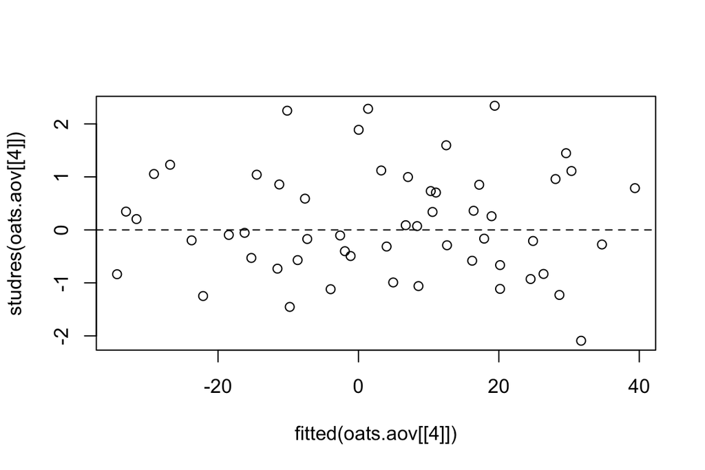

```r
# oats.aov[[4]]: fitted aov object
plot(fitted(oats.aov[[4]]), studres(oats.aov[[4]]))
abline(h = 0, lty = 2)
```

- `proj`로 원자료를 직교기저의 벡터공간으로 사영

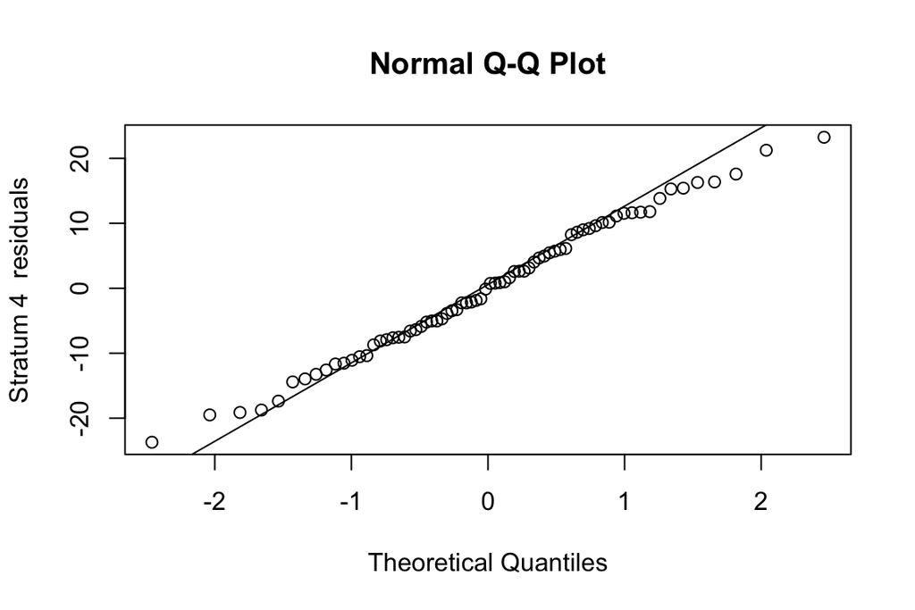

```r
oats.pr <- proj(oats.aov)
qqnorm(oats.pr[[4]] [, "Residuals"] ,  ylab =  "Stratum 4  residuals")
qqline(oats.pr[[4]][, "Residuals"])
```

#### 평균표

```r
# simplified model
oats.aov <- aov(Y ~ N + V + Error(B/V), data = oats, qr = T)
model.tables(oats.aov, type = "means", se = T)
```

```
Tables of means
Grand mean

103.9722

 N
N
0.0cwt 0.2cwt 0.4cwt 0.6cwt
 79.39  98.89 114.22 123.39

 V
V
Golden.rain  Marvellous     Victory
     104.50      109.79       97.63
```

### `lme` 모형과의 관계

```r
summary(nlme::lme(Y ~ N + V, random = ~1 | B/V, data = oats))
```

```
Linear mixed-effects model fit by REML
  Data: oats
       AIC      BIC    logLik
  586.0688 605.7756 -284.0344

Random effects:
 Formula: ~1 | B
        (Intercept)
StdDev:    14.64487

 Formula: ~1 | V %in% B
        (Intercept) Residual
StdDev:    10.47345 12.74987

Fixed effects:  Y ~ N + V
               Value Std.Error DF   t-value p-value
(Intercept) 79.91667  8.220348 51  9.721811  0.0000
N0.2cwt     19.50000  4.249955 51  4.588284  0.0000
N0.4cwt     34.83333  4.249955 51  8.196165  0.0000
N0.6cwt     44.00000  4.249955 51 10.353050  0.0000
VMarvellous  5.29167  7.078909 10  0.747526  0.4720
VVictory    -6.87500  7.078909 10 -0.971195  0.3544
 Correlation:
            (Intr) N0.2cw N0.4cw N0.6cw VMrvll
N0.2cwt     -0.259
N0.4cwt     -0.259  0.500
N0.6cwt     -0.259  0.500  0.500
VMarvellous -0.431  0.000  0.000  0.000
VVictory    -0.431  0.000  0.000  0.000  0.500

Standardized Within-Group Residuals:
        Min          Q1         Med          Q3         Max
-1.84134121 -0.66279739 -0.06694268  0.63822475  1.66066776

Number of Observations: 72
Number of Groups:
       B V %in% B
       6       18
```

```r
# 분산성분 추정
oats_lme <- lme(fixed = Y ~ N + V,
                random = ~ 1 | B/V,
                data = oats)
VarCorr(oats_lme)
```

```
            Variance     StdDev
B =         pdLogChol(1)
(Intercept) 214.4721     14.64487
V =         pdLogChol(1)
(Intercept) 109.6931     10.47345
Residual    162.5591     12.74987
```

## 비선형 혼합 효과 모형

$$y_{i j}=\mu_{i j}+\epsilon_{i j}, \quad \mu_{i j}=f\left(\boldsymbol{x}_{i j}, \boldsymbol{\beta}, \boldsymbol{\zeta}_i\right) \qquad (10.4)$$

- $f$가 비선형
- `nlme::nlme` 사용

#### `MASS::Sitka` 자료

```r
# 랜덤 절편, 랜덤 점근선
sitka.nlme <- nlme(size ~ A + B * (1 - exp(-(Time-100)/C)),
                   fixed = list(A ~ treat, B ~ treat, C ~ 1),
                   random = A + B ~ 1 | tree, data = Sitka,
                   start = list(fixed = c(2, 0, 4, 0, 100)), verbose = T)
```

```
**Iteration 1
LME step: Loglik: 56.79463, nlminb iterations: 3
reStruct  parameters:
     tree1      tree2      tree3
-1.7677947 -2.0609800  0.1082302
 Beginning PNLS step: ..  completed fit_nlme() step.
PNLS step: RSS =  4.188542
 fixed effects: 2.302929  0.174977  3.921489  -0.5645464  81.71855
 iterations: 6
Convergence crit. (must all become <= tolerance = 1e-05):
     fixed   reStruct
1.00000000 0.09720931

**Iteration 2
LME step: Loglik: 57.1434, nlminb iterations: 1
reStruct  parameters:
     tree1      tree2      tree3
-1.7699907 -2.0742358  0.1198855
 Beginning PNLS step: ..  completed fit_nlme() step.
PNLS step: RSS =  4.188542
 fixed effects: 2.302929  0.174977  3.921489  -0.5645464  81.71855
 iterations: 1
Convergence crit. (must all become <= tolerance = 1e-05):
       fixed     reStruct
0.000000e+00 7.251751e-11
```

- 비선형성으로 인해 랜덤 효과에 대한 적분이 어렵기 때문에 일반적으로 모형의 정확한 가능도를 구하는 것은 불가능
- Lindstrom and Bates (1990): 모수 $\beta$와 랜덤 효과 $\boldsymbol{\zeta}_i$에 대한 결합 최대화로 적분을 대체, 랜덤 효과의 조건부 최빈값 근방에서의 선형화로 분산 모수를 추정
  - 로그 가능도(따라서 AIC, BIC)는 근사치
  - REML 적합은 잘 정의되지 않음
  - `lme`를 반복적으로 호출
  - 시작점에 크게 의존

```r
summary(sitka.nlme)
```

```
Nonlinear mixed-effects model fit by maximum likelihood
  Model: size ~ A + B * (1 - exp(-(Time - 100)/C))
  Data: Sitka
       AIC       BIC  logLik
  -96.2868 -60.47683 57.1434

Random effects:
 Formula: list(A ~ 1, B ~ 1)
 Level: tree
 Structure: General positive-definite, Log-Cholesky parametrization
              StdDev    Corr
A.(Intercept) 0.8355691 A.(In)
B.(Intercept) 0.8195245 -0.69
Residual      0.1029752

Fixed effects:  list(A ~ treat, B ~ treat, C ~ 1)
                 Value Std.Error  DF   t-value p-value
A.(Intercept)  2.30293  0.199555 312 11.540343  0.0000
A.treatozone   0.17498  0.211706 312  0.826511  0.4091
B.(Intercept)  3.92149  0.180824 312 21.686765  0.0000
B.treatozone  -0.56455  0.215628 312 -2.618149  0.0093
C             81.71855  4.721586 312 17.307434  0.0000
 Correlation:
              A.(In) A.trtz B.(In) B.trtz
A.treatozone  -0.754
B.(Intercept) -0.699  0.593
B.treatozone   0.527 -0.715 -0.818
C              0.484 -0.066 -0.169  0.020

Standardized Within-Group Residuals:
        Min          Q1         Med          Q3         Max
-2.76151391 -0.40944261 -0.03358541  0.49269001  4.10573000

Number of Observations: 395
Number of Groups: 79
```

- 나무 내 측정값에 대한 AR(1) 상관관계 모형

```r
summary(update(sitka.nlme, corr = corCAR1(0.95, ~Time | tree), verbose = F))
```

```
Nonlinear mixed-effects model fit by maximum likelihood
  Model: size ~ A + B * (1 - exp(-(Time - 100)/C))
  Data: Sitka
        AIC       BIC   logLik
  -104.4977 -64.70888 62.24887

Random effects:
 Formula: list(A ~ 1, B ~ 1)
 Level: tree
 Structure: General positive-definite, Log-Cholesky parametrization
              StdDev    Corr
A.(Intercept) 0.8161624 A.(In)
B.(Intercept) 0.7607794 -0.674
Residual      0.1306542

Correlation Structure: Continuous AR(1)
 Formula: ~Time | tree
 Parameter estimate(s):
      Phi
0.9674962
Fixed effects:  list(A ~ treat, B ~ treat, C ~ 1)
                 Value Std.Error  DF   t-value p-value
A.(Intercept)  2.31313  0.205176 312 11.273885  0.0000
A.treatozone   0.17062  0.214451 312  0.795598  0.4269
B.(Intercept)  3.89145  0.181280 312 21.466471  0.0000
B.treatozone  -0.56357  0.216220 312 -2.606462  0.0096
C             80.93437  5.295020 312 15.284999  0.0000
 Correlation:
              A.(In) A.trtz B.(In) B.trtz
A.treatozone  -0.747
B.(Intercept) -0.698  0.599
B.treatozone   0.525 -0.721 -0.818
C              0.507 -0.070 -0.167  0.020

Standardized Within-Group Residuals:
         Min           Q1          Med           Q3          Max
-2.363159424 -0.360373516  0.002298813  0.405898895  3.547135536

Number of Observations: 395
Number of Groups: 79
```

- 관측치 간 평균 측정 간격 26.5일: 상관계수 $0.9675^{26.5} \approx 0.42$

### `MASS::Rabbit` 자료

|  |  | Dose of Phenylbiguanide $(\mu \mathrm{g})$ |  |  |  |  |  |
| --- | --- | --- | --- | --- | --- | --- | --- |
| Treatment | Rabbit | 6.25 | 12.5 | 25 | 50 | 100 | 200 |
| Placebo | 1 | 0.50 | 4.50 | 10.00 | 26.00 | 37.00 | 32.00 |
|  | 2 | 1.00 | 1.25 | 4.00 | 12.00 | 27.00 | 29.00 |
|  | 3 | 0.75 | 3.00 | 3.00 | 14.00 | 22.00 | 24.00 |
|  | 4 | 1.25 | 1.50 | 6.00 | 19.00 | 33.00 | 33.00 |
|  | 5 | 1.50 | 1.50 | 5.00 | 16.00 | 20.00 | 18.00 |
| MDL 72222 | 1 | 1.25 | 0.75 | 4.00 | 9.00 | 25.00 | 37.00 |
|  | 2 | 1.40 | 1.70 | 1.00 | 2.00 | 15.00 | 28.00 |
|  | 3 | 0.75 | 2.30 | 3.00 | 5.00 | 26.00 | 25.00 |
|  | 4 | 2.60 | 1.20 | 2.00 | 3.00 | 11.00 | 22.00 |
|  | 5 | 2.40 | 2.50 | 1.50 | 2.00 | 9.00 | 19.00 |

- 개체수 5, 2수준 처리(`Control`, `MDL`)
- 각 처리 수준에서 PBG의 용량(`Dose`)을 증가시켜 가며 10분 간격으로 정맥 주사
- 반응변수: 평균협압 변화(`BPchange`)
- PBG에 의해 유발된 심장성 화학변형이 MDL이 억제하는 5-HT$_3$ 수용체의 활성화에 의존하는가?
- 변동성의 3개 층위
  1. 토끼 개체간
  2. 토끼 개체내, 처리간
  3. 토끼 개체내, 처리 내
- `Animal/Run`에 따른 랜덤 효과

#### 비선형 모형

$$f(\alpha, \beta, \lambda, \theta, x)=\alpha+\frac{\beta-\alpha}{1+\exp [(x-\lambda) / \theta]}
, \quad
\theta > 0
, ~
x = \log(\text{dose})$$
- $\lambda$ = LD50

- 처리군(`Treatment`)별 추정

```r
Fp1 <- deriv(~ A + (B-A)/(1 + exp((log(d) - ld50)/th)),
             c("A", "B", "ld50", "th"), function(d, A, B, ld50, th){})
st <- coef(nls(BPchange ~ Fp1(Dose, A, B, ld50, th),
               start = c(A = 25, B = 0, ld50 = 4, th = 0.25),
               data = Rabbit))
Rc.nlme <- nlme::nlme(BPchange ~ Fp1(Dose, A, B, ld50, th),
                      fixed = list(A ~ 1, B ~ 1, ld50 ~ 1, th ~ 1),
                      random = A + ld50 ~ 1 | Animal, data = Rabbit,
                      subset = Treatment ==  "Control",
                      start = list(fixed = st))
Rm.nlme <- update(Rc.nlme, subset = Treatment=="MDL")
```

```r
Rc.nlme
```

```
Nonlinear mixed-effects model fit by maximum likelihood
  Model: BPchange ~ Fp1(Dose, A, B, ld50, th)
  Data: Rabbit
  Subset: Treatment == "Control"
  Log-likelihood: -66.50225
  Fixed: list(A ~ 1, B ~ 1, ld50 ~ 1, th ~ 1)
         A          B       ld50         th
28.3320185  1.5135314  3.7743776  0.2895453

Random effects:
 Formula: list(A ~ 1, ld50 ~ 1)
 Level: Animal
 Structure: General positive-definite, Log-Cholesky parametrization
         StdDev    Corr
A        5.7689133 A
ld50     0.1795311 0.112
Residual 1.3673470

Number of Observations: 30
Number of Groups: 5
```

```r
Rm.nlme
```

```
Nonlinear mixed-effects model fit by maximum likelihood
  Model: BPchange ~ Fp1(Dose, A, B, ld50, th)
  Data: Rabbit
  Subset: Treatment == "MDL"
  Log-likelihood: -65.42175
  Fixed: list(A ~ 1, B ~ 1, ld50 ~ 1, th ~ 1)
         A          B       ld50         th
27.5201227  1.7838333  4.5256831  0.2423475

Random effects:
 Formula: list(A ~ 1, ld50 ~ 1)
 Level: Animal
 Structure: General positive-definite, Log-Cholesky parametrization
         StdDev    Corr
A        5.3654156 A
ld50     0.1899683 -0.594
Residual 1.4417932

Number of Observations: 30
Number of Groups: 5
```

- 각 그룹에서 개체간 `ld50`의 랜덤 변동이 작음
- 랜덤 효과의 분포가 `Treatment`에 의존하지 않는 결합 모형을 시사

```r
c1 <- c(28, 1.6, 4.1, 0.27, 0)
R.nlme1 <- nlme::nlme(BPchange ~  Fp1(Dose, A, B, ld50, th),
                       fixed = list(A ~ Treatment, B ~ Treatment,
                        ld50 ~ Treatment, th ~ Treatment),
                       random = A + ld50 ~ 1 | Animal/Run, data = Rabbit,
                       start = list(fixed = c1[c(1, 5, 2, 5, 3, 5, 4, 5)]))
summary(R.nlme1)
```

```
Nonlinear mixed-effects model fit by maximum likelihood
  Model: BPchange ~ Fp1(Dose, A, B, ld50, th)
  Data: Rabbit
       AIC      BIC    logLik
  292.6264 324.0415 -131.3132

Random effects:
 Formula: list(A ~ 1, ld50 ~ 1)
 Level: Animal
 Structure: General positive-definite, Log-Cholesky parametrization
                 StdDev     Corr
A.(Intercept)    4.60611529 A.(In)
ld50.(Intercept) 0.06259729 -0.166

 Formula: list(A ~ 1, ld50 ~ 1)
 Level: Run %in% Animal
 Structure: General positive-definite, Log-Cholesky parametrization
                 StdDev    Corr
A.(Intercept)    3.2490527 A.(In)
ld50.(Intercept) 0.1706778 -0.348
Residual         1.4113376

Fixed effects:  list(A ~ Treatment, B ~ Treatment, ld50 ~ Treatment, th ~ Treatment)
                      Value Std.Error DF  t-value p-value
A.(Intercept)     28.325737 2.7802117 43 10.18834  0.0000
A.TreatmentMDL    -0.727488 2.5184600 43 -0.28886  0.7741
B.(Intercept)      1.524645 0.5154798 43  2.95772  0.0050
B.TreatmentMDL     0.261407 0.6459943 43  0.40466  0.6877
ld50.(Intercept)   3.778302 0.0954532 43 39.58278  0.0000
ld50.TreatmentMDL  0.747270 0.1286296 43  5.80947  0.0000
th.(Intercept)     0.289647 0.0323388 43  8.95665  0.0000
th.TreatmentMDL   -0.046876 0.0459412 43 -1.02035  0.3133
 Correlation:
                  A.(In) A.TMDL B.(In) B.TMDL l50.(I l50.TM th.(I)
A.TreatmentMDL    -0.405
B.(Intercept)     -0.040  0.044
B.TreatmentMDL     0.032 -0.076 -0.798
ld50.(Intercept)  -0.168  0.140  0.147 -0.117
ld50.TreatmentMDL  0.094 -0.154 -0.109  0.116 -0.668
th.(Intercept)     0.120 -0.133 -0.480  0.383  0.017 -0.013
th.TreatmentMDL   -0.085  0.282  0.338 -0.422 -0.012  0.094 -0.703

Standardized Within-Group Residuals:
        Min          Q1         Med          Q3         Max
-1.87814904 -0.53849465 -0.07699756  0.50948407  2.30359510

Number of Observations: 60
Number of Groups:
         Animal Run %in% Animal
              5              10
```

- `ld50`의 랜덤 변동의 대부분은 개체간(`Animal`)이 아닌 처리(`Run %in% Animal`) 사이에 발생
- `A`의 경우 두 가지 변형 계층이 모두 중요하지만 더 큰 효과는 개체간에 있음
- `ld50`만이 `Treatment`에 의존

```r
R.nlme2 <- update(R.nlme1,
                  fixed = list(A ~ 1, B ~ 1, ld50 ~ Treatment,  th ~ 1),
                  start = list(fixed = c1[c(1:3, 5, 4)]))
anova(R.nlme2,  R.nlme1)
```

```
        Model df      AIC      BIC    logLik   Test   L.Ratio p-value
R.nlme2     1 12 287.2940 312.4261 -131.6470
R.nlme1     2 15 292.6264 324.0415 -131.3132 1 vs 2 0.6676201  0.8808
```

```r
summary(R.nlme2)
```

```
Nonlinear mixed-effects model fit by maximum likelihood
  Model: BPchange ~ Fp1(Dose, A, B, ld50, th)
  Data: Rabbit
      AIC      BIC   logLik
  287.294 312.4261 -131.647

Random effects:
 Formula: list(A ~ 1, ld50 ~ 1)
 Level: Animal
 Structure: General positive-definite, Log-Cholesky parametrization
                 StdDev     Corr
A                4.66804219 A
ld50.(Intercept) 0.07260607 -0.114

 Formula: list(A ~ 1, ld50 ~ 1)
 Level: Run %in% Animal
 Structure: General positive-definite, Log-Cholesky parametrization
                 StdDev    Corr
A                3.1505100 A
ld50.(Intercept) 0.1713307 -0.376
Residual         1.4278679

Fixed effects:  list(A ~ 1, B ~ 1, ld50 ~ Treatment, th ~ 1)
                      Value Std.Error DF  t-value p-value
A                 28.170151 2.4908981 46 11.30923       0
B                  1.667327 0.3068603 46  5.43350       0
ld50.(Intercept)   3.779492 0.0921100 46 41.03239       0
ld50.TreatmentMDL  0.758881 0.1217626 46  6.23247       0
th                 0.270991 0.0226492 46 11.96468       0
 Correlation:
                  A      B      l50.(I l50.TM
B                 -0.042
ld50.(Intercept)  -0.119  0.094
ld50.TreatmentMDL  0.046 -0.033 -0.630
th                 0.146 -0.414  0.000  0.112

Standardized Within-Group Residuals:
        Min          Q1         Med          Q3         Max
-1.73998943 -0.49776345 -0.02735335  0.51963190  2.61208563

Number of Observations: 60
Number of Groups:
         Animal Run %in% Animal
              5              10
```

- 적합된 (BLUP) 곡선의 스플라인 근사

```r
xyplot(BPchange ~ log(Dose) | Animal * Treatment, Rabbit,
    xlab = "log(Dose) of Phenylbiguanide",
    ylab = "Change in blood pressure (mm Hg)",
    subscripts = TRUE, aspect = "xy", panel =
       function(x, y, subscripts) {
          panel.grid()
          panel.xyplot(x, y)
          sp <- spline(x, fitted(R.nlme2)[subscripts])
          panel.xyplot(sp$x, sp$y, type = "l")
       })
```

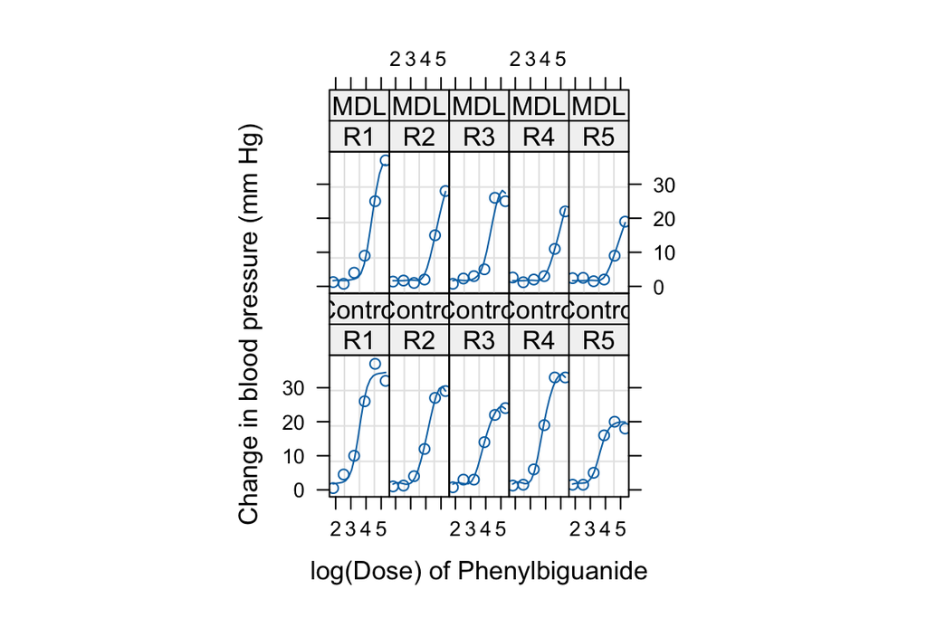

## 일반화 선형 혼합 모형

- 선형 예측 변수에 랜덤 효과가 포함된 일반화 선형 모형 이다. $m$ 단위 $i$에 대해 $j$로 색인된 관측값이 있는 경우,
  $$E\left[Y_{i j} \mid \boldsymbol{\zeta}_i\right]=g^{-1}\left(\eta_{i j}\right), \quad \eta_{i j}=\boldsymbol{x}_{i j} \boldsymbol{\beta}+\boldsymbol{z}_{i j} \boldsymbol{\zeta}_i$$
  - $i$: 단위 번호, $j$: 관측 번호
- 연결 함수 $g$: 랜덤 효과 $\boldsymbol{\zeta}$에 조건부로 표준 GLM
- 가능도
  $$L(\boldsymbol{\beta} ; Y)=\underset{i}{\prod} \int e^{\sum_j^{\ell\left(\theta ; Y_{i j}\right)}} p\left(\boldsymbol{\zeta}_i\right) \mathrm{d} \boldsymbol{\zeta}_i$$
  - $\ell(\theta; Y_{ij}) = \sum_i [A_i(Y_{ij}\theta_i - \gamma(\theta_i))/\varphi + \tau(Y_{ij}, \phi/A_i)]$
  - $\theta_i = (\gamma^\prime)^{-1}(\mu_i)=(\gamma^\prime)^{-1}(g^{-1}(\eta_i))$: $\boldsymbol{\beta}$, $\boldsymbol{\zeta}_i$에 의존
- 랜덤 효과는 평균이 0이고 공분산 행렬이 $D$인 정규 분포를 따른다고 가정
- 최종 가능도 함수
  $$L(\boldsymbol{\beta} ; Y) \propto|D|^{-m / 2} \underset{i}{\prod} \int \exp \kappa_i\left(\boldsymbol{\zeta}_i\right) \mathrm{d} \boldsymbol{\zeta}_i, \quad \kappa_i\left(\boldsymbol{\zeta}_i\right)=\underset{j}{\sum} \ell\left(\theta ; Y_{i j}\right)+\boldsymbol{\zeta}_i^T D^{-1} \boldsymbol{\zeta}_i$$
- 적분계산의 어려움 – 이론적 근사 또는 적분에 대한 수치 근사
  - 수치 적분: 적응적 가우스 구적법(Adaptive Gaussian Quadrature), 라플라스 근사 등
  - 마르코프 사슬 몬테 카를로(Markov chain Monte Carlo)
  - 벌점화 준가능도(Penalized Quasi-Likelihood)

#### `MASS::epil` 자료

- 59명의 뇌전증(간질) 환자에 대한 2주간의 발작 횟수(`y`)에 대한 자료
- 8주간의 기준 기간 동안의 발작 횟수(`base`)를 기록한 후 환자를 무작위로 처리군 또는 대조군으로 배정(`trt`)
- 2주 주기로 4회 연달아 횟수를 기록(`period`)
- 공변량: `age`
- 8주 + 8주 기간 동안 5회 측정된 자료로 간주

```r
epil1 <- epil
epil2 <-  epil1[epil1$period ==  1,  ]
epil2["period"] <- rep(0,  59);  epil2["y"] <- epil2["base"]
epil1["time"] <- 1;  epil2["time"] <- 4
epil2 <- rbind(epil1, epil2)
epil2$pred <- unclass(epil2$trt) *  (epil2$period > 0)
epil2$subject <- factor(epil2$subject)
epil3 <- aggregate(epil2, list(epil2$subject, epil2$period > 0), function(x) if(is.numeric(x)) sum(x)  else x[1])
epil3$pred <- factor(epil3$pred, labels = c("base", "placebo", "drug"))
contrasts(epil3$pred) <- structure(contr.sdif(3), dimnames = list(NULL, c("placebo-base", "drug-placebo")))
```

### 수치 적분

- `lme4::glmer`는 라플라스 근사를 사용

```r
library(lme4)
# Model 1: Full interaction model
epil_mod1 <- glmer(y ~ lbase * trt + lage + V4 + (1 | subject),
                   family = poisson,
                   data = epil)
summary(epil_mod1)
```

```
Generalized linear mixed model fit by maximum likelihood (Laplace
  Approximation) [glmerMod]
 Family: poisson  ( log )
Formula: y ~ lbase * trt + lage + V4 + (1 | subject)
   Data: epil

      AIC       BIC    logLik -2*log(L)  df.resid
   1344.7    1369.0    -665.4    1330.7       229

Scaled residuals:
    Min      1Q  Median      3Q     Max
-3.1918 -0.8456 -0.0918  0.5837  6.6303

Random effects:
 Groups  Name        Variance Std.Dev.
 subject (Intercept) 0.2515   0.5015
Number of obs: 236, groups:  subject, 59

Fixed effects:
                   Estimate Std. Error z value Pr(>|z|)
(Intercept)          1.8339     0.1052  17.438  < 2e-16 ***
lbase                0.8844     0.1308   6.764 1.34e-11 ***
trtprogabide        -0.3349     0.1474  -2.272  0.02311 *
lage                 0.4845     0.3458   1.401  0.16123
V4                  -0.1611     0.0543  -2.966  0.00301 **
lbase:trtprogabide   0.3383     0.2025   1.671  0.09479 .
---
Signif. codes:  0 '***' 0.001 '**' 0.01 '*' 0.05 '.' 0.1 ' ' 1

Correlation of Fixed Effects:
            (Intr) lbase  trtprg lage   V4
lbase       -0.035
trtprogabid -0.704  0.024
lage        -0.092 -0.037  0.099
V4          -0.114  0.000  0.000  0.000
lbs:trtprgb  0.001 -0.654 -0.087  0.252  0.000
```

```r
# Model 2: Reduced model on aggregated data
epil_mod2 <- glmer(y ~ pred + (1 | subject),
                   family = poisson,
                   data = epil3)
summary(epil_mod2)
```

```
Generalized linear mixed model fit by maximum likelihood (Laplace
  Approximation) [glmerMod]
 Family: poisson  ( log )
Formula: y ~ pred + (1 | subject)
   Data: epil3

      AIC       BIC    logLik -2*log(L)  df.resid
   1147.6    1158.7    -569.8    1139.6       114

Scaled residuals:
    Min      1Q  Median      3Q     Max
-4.8698 -0.7896 -0.0162  0.6577  5.1070

Random effects:
 Groups  Name        Variance Std.Dev.
 subject (Intercept) 0.6084   0.78
Number of obs: 118, groups:  subject, 59

Fixed effects:
                 Estimate Std. Error z value Pr(>|z|)
(Intercept)       3.13890    0.10397  30.190   <2e-16 ***
predplacebo-base  0.11143    0.04641   2.401   0.0164 *
preddrug-placebo -0.10486    0.06400  -1.638   0.1014
---
Signif. codes:  0 '***' 0.001 '**' 0.01 '*' 0.05 '.' 0.1 ' ' 1

Correlation of Fixed Effects:
            (Intr) prdpl-
predplcb-bs  0.037
prddrg-plcb -0.006 -0.716
```

### PQL 방법

- 벌점화 준가능도(Penalized Quasi-Likelihood)
- GLM에 대한 IWLS 알고리즘은 평균 $\mu$의 현재 추정치에서 해를 선형 근사하고 임시 가중치 $W$로 임시 반응변수 $z$를 최소제곱법으로 선형회귀
- PQL에서는 GLMM에 최소제곱법 대신 선형 혼합효과 모형 적합을 사용하여 고정 효과, 즉 평균을 추정
- 선형 혼합효과 모형 적합은 분산 성분의 현재 추정치에 의존 — BLUP과 잔차제곱합으로부터 MLE와 REML 추정
- 동등하게 $\int \exp \kappa_i\left(\boldsymbol{\zeta}_i\right) \mathrm{d} \boldsymbol{\zeta}_i$에 라플라스 근사(최대값 근방에서 2차 테일러 전개)를 적용하는 것으로 해석 가능

```r
summary(MASS::glmmPQL(y ~ lbase*trt + lage + V4,
                random = ~ 1 | subject,
                family = poisson, data =  epil3))
```

```
Linear mixed-effects model fit by maximum likelihood
  Data: epil3
  AIC BIC logLik
   NA  NA     NA

Random effects:
 Formula: ~1 | subject
         (Intercept) Residual
StdDev: 5.796441e-05 3.106931

Variance function:
 Structure: fixed weights
 Formula: ~invwt
Fixed effects:  y ~ lbase * trt + lage + V4
                       Value  Std.Error DF  t-value p-value
(Intercept)         3.469688 0.09643075 57 35.98114  0.0000
lbase               0.302162 0.03390191 55  8.91284  0.0000
trtprogabide       -0.122688 0.12299790 57 -0.99748  0.3227
lage                0.222535 0.09094734 55  2.44686  0.0176
V4                 -0.444997 0.12505398 55 -3.55844  0.0008
lbase:trtprogabide  0.093036 0.04366186 55  2.13083  0.0376
 Correlation:
                   (Intr) lbase  trtprg lage   V4
lbase              -0.242
trtprogabide       -0.635  0.329
lage               -0.052 -0.023  0.054
V4                 -0.423 -0.399 -0.012 -0.129
lbase:trtprogabide  0.294 -0.668 -0.472  0.374 -0.022

Standardized Within-Group Residuals:
       Min         Q1        Med         Q3        Max
-1.8160229 -0.6986396 -0.1907136  0.4388380  4.0548079

Number of Observations: 118
Number of Groups: 59
```

```r
summary(MASS::glmmPQL(y ~ pred, random = ~ 1 | subject,
                      family = poisson, data = epil3))
```

```
Linear mixed-effects model fit by maximum likelihood
  Data: epil3
  AIC BIC logLik
   NA  NA     NA

Random effects:
 Formula: ~1 | subject
        (Intercept) Residual
StdDev:   0.7260474 2.169273

Variance function:
 Structure: fixed weights
 Formula: ~invwt
Fixed effects:  y ~ pred
                     Value  Std.Error DF   t-value p-value
(Intercept)       3.214199 0.10574213 58 30.396582  0.0000
predplacebo-base  0.112880 0.09997031 57  1.129132  0.2636
preddrug-placebo -0.107590 0.13493917 57 -0.797319  0.4286
 Correlation:
                 (Intr) prdpl-
predplacebo-base  0.081
preddrug-placebo -0.010 -0.700

Standardized Within-Group Residuals:
       Min         Q1        Med         Q3        Max
-2.0412058 -0.4766737 -0.1992579  0.3179334  2.6501959

Number of Observations: 118
Number of Groups: 59
```

## GEE 모형

- 선형 혼합효과 모형
  $$y_{i j}=\mu_{i j}+\boldsymbol{z}_{i j} \boldsymbol{\zeta}_i+\epsilon_{i j}, \quad \mu_{i j}=\boldsymbol{x}_{i j} \boldsymbol{\beta}$$
  - $y_{ij}$는 주변분포로 평균이 $\mu_{ij}$이고 공분산 행렬이 계산 가능한 다변량 정규분포를 갖는 비독립 확률변수
  - `lme`의 최대 가능도 적합은 정규 주변 가능도를 최대화
- 주변 GLM
  $$Y_{i j} \sim \operatorname{family}\left(g^{-1}\left(\eta_{i j}\right)\right), \quad \eta_{i j}=\boldsymbol{x}_{i j} \boldsymbol{\beta}$$
  - **$Y_{ij}$의 상관관계 구조를 가정**
- 일반화 추정 방정식(generalized estimating equation)으로 적합(Liang and Zeger, 1986; Diggle et al, 1994)
  - 약한 조건에서 점근적 불편근사
- GLMM (예: 로그 연결함수)
  $$E Y_{i j}=E \exp \left(\boldsymbol{x}_{i j} \boldsymbol{\beta}+\zeta_i\right)=g^{-1}\left(\boldsymbol{x}_{i j} \boldsymbol{\beta}\right) \times E e^{\zeta_1}$$
  - $Y_{ij}$는 상관 관계가 있지만 연결 $g$가 선형이 아닌 한 그 평균은 더 이상 $\mu_{ij} = g^{-1}(\eta_{ij})$가 아님
  - 주변분포가 포아송이 아님

```r
library(gee)
options(contrasts = c("contr.sum", "contr.poly"))
summary(gee(y ~ pred + factor(subject), family = poisson,
            id = subject,data = epil3, corstr = "exchangeable"))
```

[output not shown]

```
 GEE:  GENERALIZED LINEAR MODELS FOR DEPENDENT DATA
 gee S-function, version 4.13 modified 98/01/27 (1998)

Model:
 Link:                      Logarithm
 Variance to Mean Relation: Poisson
 Correlation Structure:     Exchangeable

Call:
gee(formula = y ~ pred + factor(subject), id = subject, data = epil3,
    family = poisson, corstr = "exchangeable")

Summary of Residuals:
          Min            1Q        Median            3Q           Max
-7.469395e+01 -3.181507e+00  3.952394e-14  3.181507e+00  7.469395e+01


Coefficients:
                     Estimate Naive S.E.    Naive z Robust S.E.    Robust z
(Intercept)        3.13053565 0.05118279 61.1638379  0.02983431 104.9307301
predplacebo-base   0.11079814 0.10578308  1.0474089  0.08222054   1.3475726
preddrug-placebo  -0.10368067 0.14676726 -0.7064292  0.15111408  -0.6861086
factor(subject)1  -0.62243462 0.44806669 -1.3891562  0.06639283  -9.3750282
factor(subject)2  -0.62243462 0.44806669 -1.3891562  0.06639283  -9.3750282
factor(subject)3  -1.00809710 0.54159444 -1.8613505  0.17304223  -5.8257288
factor(subject)4  -0.79678800 0.48808692 -1.6324715  0.13613172  -5.8530667
factor(subject)5   0.95448010 0.21144947  4.5139866  0.11297204   8.4488171
factor(subject)6   0.05050986 0.32314856  0.1563054  0.11988412   0.4213223
factor(subject)7  -0.66325661 0.45712060 -1.4509445  0.06218944 -10.6651006
factor(subject)8   1.14912214 0.19370873  5.9322167  0.17233321   6.6680248
factor(subject)9  -0.03464795 0.33666786 -0.1029143  0.07278420  -0.4760367
factor(subject)10 -0.08011033 0.34413329 -0.2327887  0.33709920  -0.2376461
factor(subject)11  0.92937418 0.21387863  4.3453344  0.06580584  14.1229742
factor(subject)12  0.30182428 0.28657347  1.0532178  0.08671174   3.4807776
factor(subject)13 -0.31494992 0.38561422 -0.8167487  0.09322179  -3.3785010
factor(subject)14  0.58950636 0.25022248  2.3559288  0.06221435   9.4754076
factor(subject)15  1.14229618 0.19429922  5.8790570  0.17898901   6.3819346
factor(subject)16  0.34834430 0.28031504  1.2426886  0.39995559   0.8709574
factor(subject)17 -0.66325661 0.45712060 -1.4509445  0.38921339  -1.7040950
factor(subject)18  1.61401067 0.15838616 10.1903519  0.04893703  32.9813778
```

[output cut: 33 more lines]

```
factor(subject)52 -0.05027308 0.34764858 -0.1446089  0.36944242  -0.1360782
factor(subject)53  1.04833921 0.20689923  5.0669073  0.08787384  11.9300494
factor(subject)54 -0.17702478 0.36970385 -0.4788286  0.21414661  -0.8266523
factor(subject)55 -0.35395549 0.40299314 -0.8783164  0.05246493  -6.7465164
factor(subject)56  0.50251675 0.26672331  1.8840376  0.27751744   1.8107574
factor(subject)57 -0.35395549 0.40299314 -0.8783164  0.43094613  -0.8213451
factor(subject)58 -1.22299334 0.61808927 -1.9786678  0.69902732  -1.7495644

Estimated Scale Parameter:  5.089828
Number of Iterations:  1

Working Correlation
     [,1] [,2]
[1,]    1    0
[2,]    0    0
```

- GLMM에서 $\boldsymbol{\beta}$는 개인에 대한 공변량의 효과를 측정
- GEE 모형에서는 일반적으로 모집단에 미치는 영향을 측정 (보통 더 작음)